# nypd_report.Rmd

Valentina Anthonio

2023-06-22

## Data Science as Field NYPD SHOOTING INCIDENT DATA project

This report presents the findings from the [nypd shooting data](https://data.cityofnewyork.us/api/views/833y-fsy8/rows.csv?accessType=DOWNLOAD) which covers shooting incidences of five different boroughs spanning from January 01 2006 to December 31 2022. The report focuses on the the distribution of cases by the hour, location and gender distribution.

```r
library(tidyverse)
library(lubridate)
library(gridExtra)
library(dplyr)
library(knitr)
library(magrittr)
library(ggtext)
library(ggpie)
```

## Data Sources

### Import data

The data used for this analysis was extracted from [DATA.GOV](https://data.cityofnewyork.us/api/views/833y-fsy8/rows.csv?accessType=DOWNLOAD)

```r
url_in <-"https://data.cityofnewyork.us/api/views/833y-fsy8/rows.csv?accessType=DOWNLOAD"
df_ny <-read_csv(url_in)
```

### Data Cleaning and Exploration

```r
head(df_ny,5)
```

```
## # A tibble: 5 × 21
##   INCIDENT_KEY OCCUR_DATE OCCUR_TIME BORO   LOC_OF_OCCUR_DESC PRECINCT
##          <dbl> <chr>      <time>     <chr>  <chr>                <dbl>
## 1    228798151 05/27/2021 21:30      QUEENS <NA>                   105
## 2    137471050 06/27/2014 17:40      BRONX  <NA>                    40
## 3    147998800 11/21/2015 03:56      QUEENS <NA>                   108
## 4    146837977 10/09/2015 18:30      BRONX  <NA>                    44
## 5     58921844 02/19/2009 22:58      BRONX  <NA>                    47
## # ℹ 15 more variables: JURISDICTION_CODE <dbl>, LOC_CLASSFCTN_DESC <chr>,
## #   LOCATION_DESC <chr>, STATISTICAL_MURDER_FLAG <lgl>, PERP_AGE_GROUP <chr>,
## #   PERP_SEX <chr>, PERP_RACE <chr>, VIC_AGE_GROUP <chr>, VIC_SEX <chr>,
## #   VIC_RACE <chr>, X_COORD_CD <dbl>, Y_COORD_CD <dbl>, Latitude <dbl>,
## #   Longitude <dbl>, Lon_Lat <chr>
```

```r
#drop some columns from the data
df_ny <- df_ny %>% select(-c(INCIDENT_KEY,PRECINCT,JURISDICTION_CODE,LOC_OF_OCCUR_DESC,LOC_CLASSFCTN_DESC,X_COORD_CD,Y_COORD_CD,Latitude,Longitude,Lon_Lat))
```

```r
#replace n/a values with unknown
df_ny <- df_ny %>% replace_na(list(PERP_AGE_GROUP="Unknown",PERP_SEX="Unknown", PERP_RACE="Unknown", VIC_AGE_GROUP="Unknown",VIC_SEX="Unknown", VIC_RACE="Unknown",LOCATION_DESC="Unknown"))
```

```r
#merge n/a, null and unknown values into one.
df_ny$PERP_AGE_GROUP = recode(df_ny$PERP_AGE_GROUP, UNKNOWN ="Unknown")
df_ny$PERP_AGE_GROUP = recode(df_ny$PERP_AGE_GROUP,"(null)" = "Unknown")
df_ny$PERP_AGE_GROUP = recode(df_ny$PERP_AGE_GROUP, "N/A" = "Unknown")
df_ny$VIC_AGE_GROUP = recode(df_ny$VIC_AGE_GROUP, UNKNOWN = "UnKnown")
df_ny$VIC_AGE_GROUP = as.factor(df_ny$VIC_AGE_GROUP)
df_ny$PERP_SEX = recode(df_ny$PERP_SEX,"(null)" = "Unknown")
df_ny$VIC_RACE = recode(df_ny$VIC_RACE,UNKNOWN ="Unknown")
df_ny$LOCATION_DESC = recode(df_ny$LOCATION_DESC,"(null)" = "Unknown")

# convert TRUE/FALSE to 1 and 0
df_ny$STATISTICAL_MURDER_FLAG[df_ny$STATISTICAL_MURDER_FLAG=="TRUE"] <-1
df_ny$STATISTICAL_MURDER_FLAG[df_ny$STATISTICAL_MURDER_FLAG =="FALSE"]<- 0

#convert date column of date formate
df_ny$OCCUR_DATE <- mdy(df_ny$OCCUR_DATE)
df_ny$OCCUR_TIME <- hour(hms(as.character(df_ny$OCCUR_TIME)))

#rename columns
df_ny <- df_ny %>% rename(DATE = OCCUR_DATE,
                      TIME = OCCUR_TIME)
head(df_ny)
```

```
## # A tibble: 6 × 11
##   DATE        TIME BORO     LOCATION_DESC STATISTICAL_MURDER_FLAG PERP_AGE_GROUP
##   <date>     <dbl> <chr>    <chr>                           <dbl> <chr>
## 1 2021-05-27    21 QUEENS   Unknown                             0 Unknown
## 2 2014-06-27    17 BRONX    Unknown                             0 Unknown
## 3 2015-11-21     3 QUEENS   Unknown                             1 Unknown
## 4 2015-10-09    18 BRONX    Unknown                             0 Unknown
## 5 2009-02-19    22 BRONX    Unknown                             1 25-44
## 6 2020-10-21    21 BROOKLYN Unknown                             1 Unknown
## # ℹ 5 more variables: PERP_SEX <chr>, PERP_RACE <chr>, VIC_AGE_GROUP <fct>,
## #   VIC_SEX <chr>, VIC_RACE <chr>
```

```r
# get the age groupings of victims and perpetrators
table(df_ny$VIC_AGE_GROUP)
```

```
##
##     <18    1022   18-24   25-44   45-64     65+ UnKnown
##    2839       1   10086   12281    1863     181      61
```

```r
table(df_ny$PERP_AGE_GROUP)
```

```
##
##     <18    1020   18-24     224   25-44   45-64     65+     940 Unknown
##    1591       1    6222       1    5687     617      60       1   13132
```

```r
#drop the outliers in the age groups
df_ny <- df_ny[!(df_ny$PERP_AGE_GROUP ==1020 ),]
df_ny <- df_ny[!(df_ny$PERP_AGE_GROUP ==940 ),]
df_ny <- df_ny[!(df_ny$PERP_AGE_GROUP ==224 ),]
df_ny <- df_ny[!(df_ny$VIC_AGE_GROUP ==1022),]


table(df_ny$VIC_AGE_GROUP)
```

```
##
##     <18    1022   18-24   25-44   45-64     65+ UnKnown
##    2839       0   10085   12279    1863     181      61
```

```r
table(df_ny$PERP_AGE_GROUP)
```

```
##
##     <18   18-24   25-44   45-64     65+ Unknown
##    1591    6221    5687     617      60   13132
```

### Data Exploration

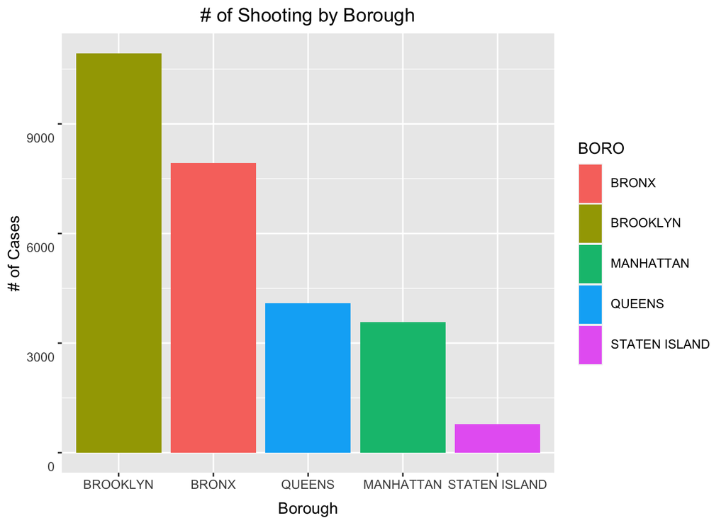

```r
#plot data points
#get cases group by sex
shooting <- df_ny %>% group_by(BORO) %>% summarize(incidents = n())

ggplot(shooting,aes(reorder(BORO,-incidents), y= incidents, fill=BORO)) +geom_bar(stat = "identity",position = "dodge") + xlab("Borough") + ylab("# of Cases") +
  ggtitle("# of Shooting by Borough") +theme(plot.title = element_text(hjust = 0.5), axis.text.y = element_text(vjust= 2), axis.title.x = element_text(vjust = -1), legend.text = element_markdown(margin=margin(t=10, b=10, unit="pt")))
```

From the graph above, its evident that most of the shootings took place in the Brooklyn followed by the Bronx with Staten Island being the least.

```r
# get the number of shooting incidents by location
table(df_ny$LOCATION_DESC)
```

```
##
##                       ATM                      BANK            BAR/NIGHT CLUB
##                         1                         3                       627
##         BEAUTY/NAIL SALON               CANDY STORE               CHAIN STORE
##                       112                         7                         5
##                CHECK CASH         CLOTHING BOUTIQUE           COMMERCIAL BLDG
##                         1                        14                       292
##                DEPT STORE            DOCTOR/DENTIST                DRUG STORE
##                         9                         1                        14
##       DRY CLEANER/LAUNDRY         FACTORY/WAREHOUSE                 FAST FOOD
##                        31                         8                       104
##               GAS STATION            GROCERY/BODEGA      GYM/FITNESS FACILITY
##                        70                       694                         3
##                  HOSPITAL               HOTEL/MOTEL             JEWELRY STORE
##                        65                        35                        12
##              LIQUOR STORE              LOAN COMPANY   MULTI DWELL - APT BUILD
##                        41                         1                      2835
## MULTI DWELL - PUBLIC HOUS                      NONE          PHOTO/COPY STORE
##                      4831                       175                         1
##                 PVT HOUSE          RESTAURANT/DINER                    SCHOOL
##                       951                       204                         1
##                SHOE STORE            SMALL MERCHANT SOCIAL CLUB/POLICY LOCATI
##                        10                        37                        72
##          STORAGE FACILITY        STORE UNCLASSIFIED               SUPERMARKET
##                         1                        36                        21
##           TELECOMM. STORE                   Unknown             VARIETY STORE
##                        11                     15953                        11
##               VIDEO STORE
##                         8
```

```r
shooting<- df_ny %>%
  group_by(LOCATION_DESC) %>%
  reframe(total_shootings =n(), paste(round(total_shootings/(count(df_ny))*100,2), "%")) %>%
  arrange(desc(total_shootings))

shooting<- shooting %>% rename(percentage = 3)

shooting
```

```
## # A tibble: 40 × 3
##    LOCATION_DESC             total_shootings percentage
##    <chr>                               <int> <chr>
##  1 Unknown                             15953 58.42 %
##  2 MULTI DWELL - PUBLIC HOUS            4831 17.69 %
##  3 MULTI DWELL - APT BUILD              2835 10.38 %
##  4 PVT HOUSE                             951 3.48 %
##  5 GROCERY/BODEGA                        694 2.54 %
##  6 BAR/NIGHT CLUB                        627 2.3 %
##  7 COMMERCIAL BLDG                       292 1.07 %
##  8 RESTAURANT/DINER                      204 0.75 %
##  9 NONE                                  175 0.64 %
## 10 BEAUTY/NAIL SALON                     112 0.41 %
## # ℹ 30 more rows
```

58.4% of most shootings had no specific location information but multi dwelling public places had **17.69%** following by multi dwelling apartment of **10.38%**.

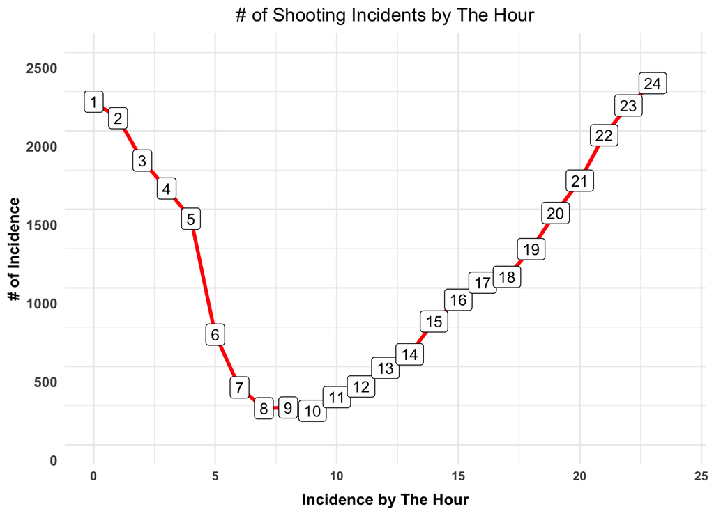

```r
#check which day of the week has most cases
defaultW <-getOption("warn")
options(warning=-1)

# get shooting data by the hour
df_hour <- df_ny %>%  group_by(TIME) %>% count()

ggplot(df_hour, aes(x=TIME, y=n)) + geom_line(color="red", linewidth=1.2) + labs(x= "Incidence by The Hour", y="# of Incidence") + theme_minimal() + geom_point(color="blue", size=2)+ggtitle("# of Shooting Incidents by The Hour")+theme(plot.title = element_text(hjust=0.5), axis.text.x = element_text(face="bold"), axis.text.y = element_text(vjust= 2, size=10, face="bold"), axis.title.x = element_text(vjust = -1, face="bold"), axis.title.y = element_text(face="bold"), legend.text = element_markdown(margin=margin(t=10, b=10, unit="pt"))) + ylim(0, 2500)+ geom_label(label=rownames(df_hour)) + scale_x_continuous(limits=c(0,24))
```

```r
# perpetrator age distribution
options(repr.plot.width = 25, repr.plot.height=25)

perp_b<- ggplot(data=df_ny)  +  geom_bar(mapping = aes(x=PERP_AGE_GROUP, fill=PERP_AGE_GROUP), show.legend = FALSE, width=1) + theme(aspect.ratio = 1, plot.title=element_text(hjust=0.5), panel.border = element_blank()) + labs(x=NULL, y=NULL) + coord_polar() + ggtitle("Perpetrator Age Group Distribution") +scale_color_viridis_d()+ scale_fill_viridis_d()

perp_flip <- perp_b + coord_flip()+
  theme(axis.text.x = element_blank())  + geom_text(aes(x=PERP_AGE_GROUP, label = ..count..), size=3, fontface="bold", stat="count", position = position_stack(vjust = 0.75))
```

[output not shown]

```r
options(repr.plot.width = 25, repr.plot.height=25)

vict_b <- ggplot(data=df_ny) + geom_bar(mapping = aes(x=VIC_AGE_GROUP, fill=VIC_AGE_GROUP),show.legend = FALSE, width=1) + theme(aspect.ratio = 1, plot.title = element_text(hjust=0.5), panel.border = element_blank()) + labs(x=NULL, y=NULL) + coord_polar() + ggtitle("Victim Age Group Distribution") + scale_fill_brewer(palette = "Dark2")

vict_b_flip <- vict_b + coord_flip()+
  theme(axis.text.x = element_blank())  + geom_text(aes(x=VIC_AGE_GROUP, label = ..count..), size=3, fontface="bold", stat="count", position = position_stack(vjust = 0.75))
```

[output not shown]

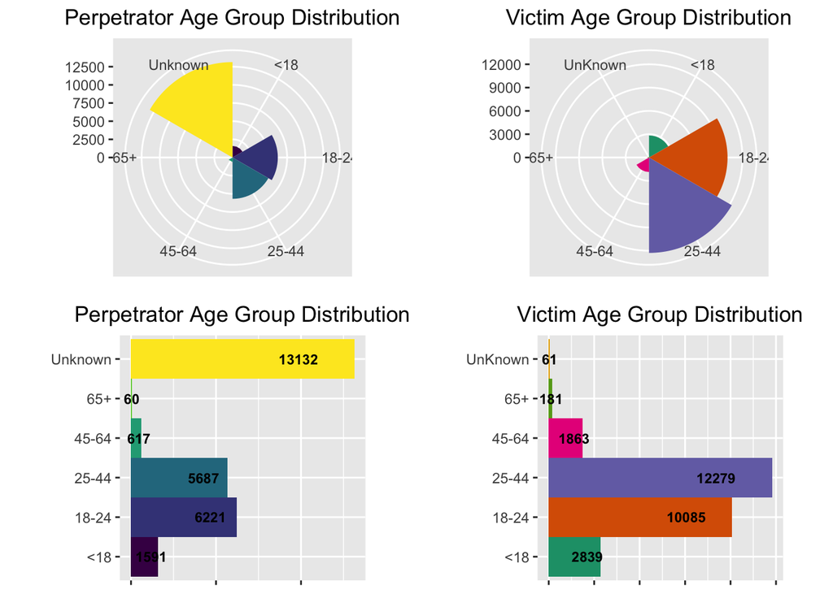

```r
grid.arrange(perp_b, vict_b, perp_flip, vict_b_flip, ncol=2)
```

With the age group of most perpetrators unknown, significant grouped after this were between the ages of 18-24 and 25-44 with the reverse being the case of victims where most victims were between 25-44 followed by 18-24 with about 61 cases classified as unknown.

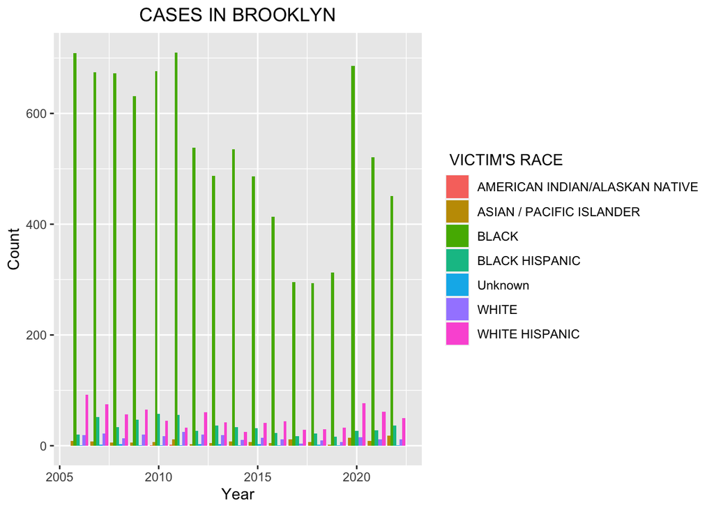

```r
df_ny %>% filter(BORO =='BROOKLYN') %>% ggplot(aes(x = year(DATE), fill = VIC_RACE)) +
  geom_bar(position = 'dodge') +
  labs(x = "Year", y = "Count", fill = " VICTIM'S RACE",title= "CASES IN BROOKLYN") + theme(plot.title = element_text(hjust = 0.5))
```

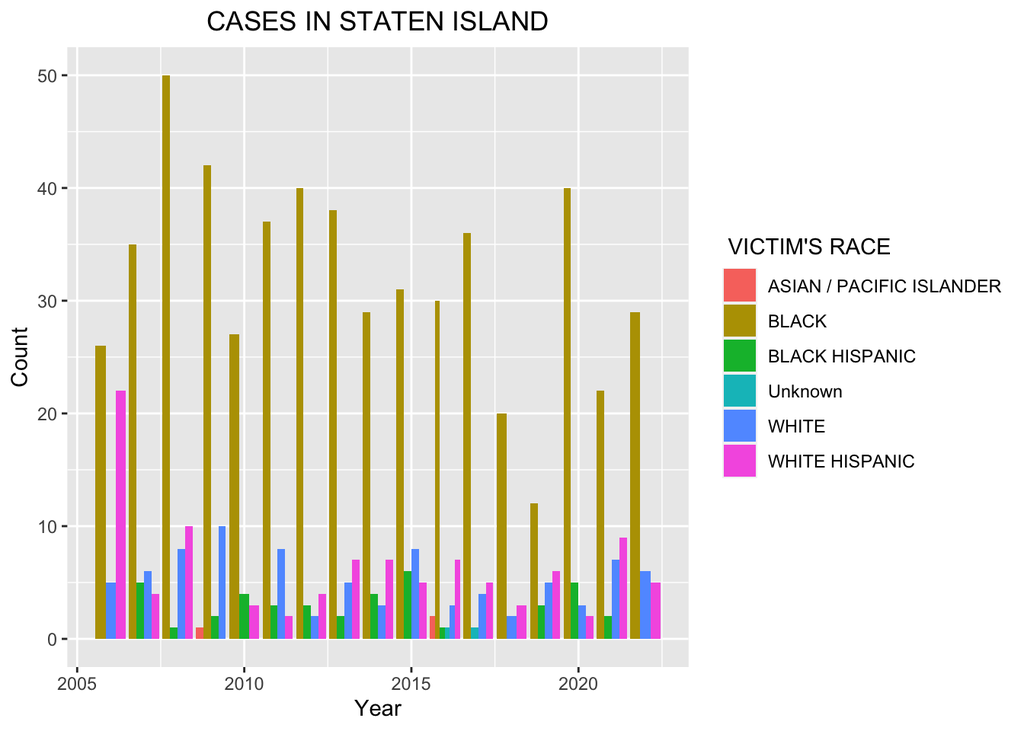

```r
df_ny %>% filter(BORO =='STATEN ISLAND') %>% ggplot(aes(x = year(DATE), fill = VIC_RACE)) +
  geom_bar(position = 'dodge') +
  labs(x = "Year", y = "Count", fill = " VICTIM'S RACE",title= "CASES IN STATEN ISLAND") + theme(plot.title = element_text(hjust = 0.5))
```

Both graphs represent the locations with the highest and lowest occurrence of cases. It is evident that the majority of victims were Black, followed by White Hispanics.

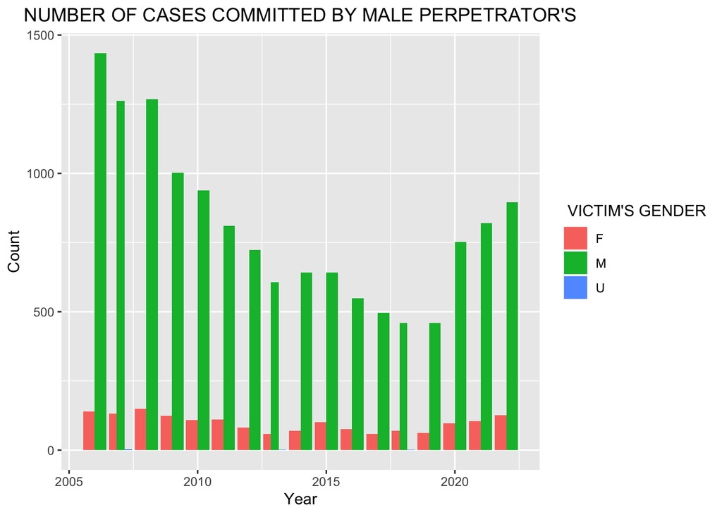

```r
df_ny %>% filter(PERP_SEX =='M') %>% ggplot(aes(x = year(DATE), fill = VIC_SEX)) +
  geom_bar(position = 'dodge') +
  labs(x = "Year", y = "Count", fill = " VICTIM'S GENDER",title= "NUMBER OF CASES COMMITTED BY MALE PERPETRATOR'S") + theme(plot.title = element_text(hjust = 0.5))
```

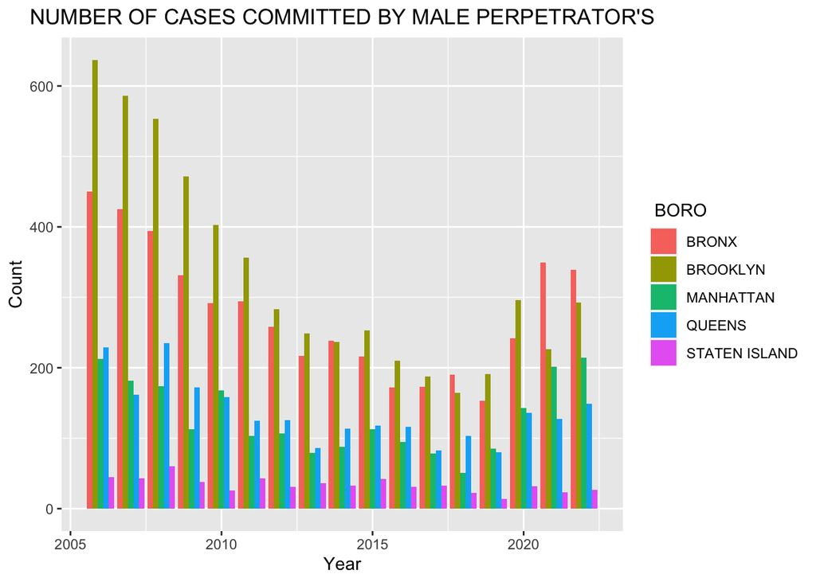

```r
df_ny %>% filter(PERP_SEX =='M') %>% ggplot(aes(x = year(DATE), fill = BORO)) +
  geom_bar(position = 'dodge') +
  labs(x = "Year", y = "Count", fill = " BORO",title= "NUMBER OF CASES COMMITTED BY MALE PERPETRATOR'S") + theme(plot.title = element_text(hjust = 0.5))
```

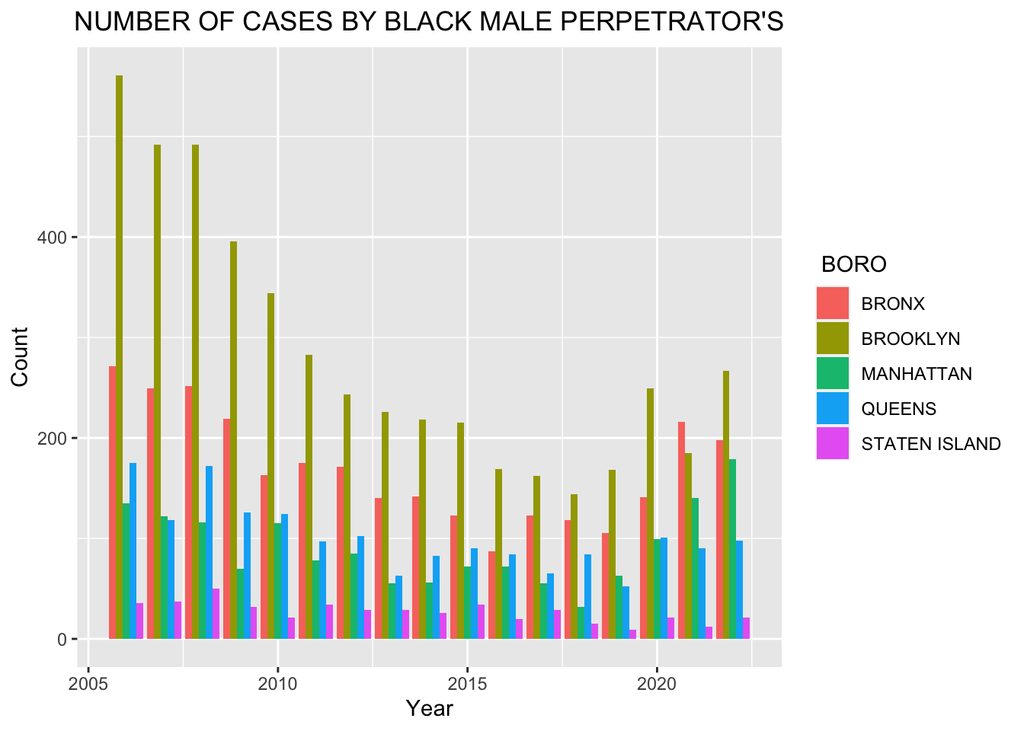

```r
df_ny %>% filter(PERP_RACE=='BLACK') %>% ggplot(aes(x = year(DATE), fill = BORO)) +
  geom_bar(position = 'dodge') +
  labs(x = "Year", y = "Count", fill = " BORO",title= "NUMBER OF CASES BY BLACK MALE PERPETRATOR'S") + theme(plot.title = element_text(hjust = 0.5))
```

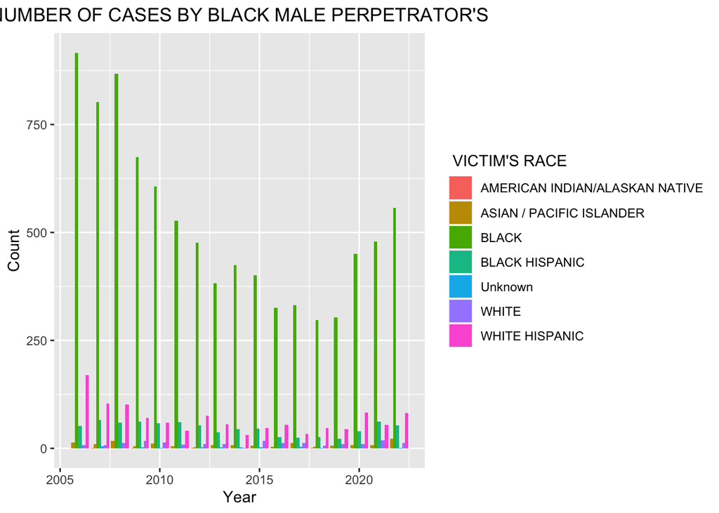

```r
 df_ny %>% filter(PERP_RACE =="BLACK" & PERP_SEX =="M") %>% ggplot(aes(x = year(DATE), fill = VIC_RACE)) +
  geom_bar(position = 'dodge') +
  labs(x = "Year", y = "Count", fill = " VICTIM'S RACE",title= "NUMBER OF CASES BY BLACK MALE PERPETRATOR'S") + theme(plot.title = element_text(hjust = 0.5))
```

These plots display the distribution of cases involving male perpetrators based on gender and the neighbourhood. The distribution patterns for cases committed by Black males were similar to those for cases committed by males in general.